# Entrega grupal

Eli, Jazmín, Flor, Shengnan, Mariajo

## Paquetes necesarios

> Insertad aquí todos los paquetes vayáis necesitando

```r
rm(list = ls())
library(tidyverse)
library(glue)
library(forcats)
library(lubridate)
library(waffle)
library(gganimate)
```

## Entrega grupal

### Datos

La práctica se basará en los **archivos de datos electorales** que se indican a continuación, recopilando datos sobre las elecciones al Congreso de los Diputados en España desde 2008 hasta la actualidad, así como encuestas, códigos de municipios y abreviaturas

```r
# NO TOQUES NADA
election_data <- read_csv(file = "./data/datos_elecciones_brutos.csv")
cod_mun <- read_csv(file = "./data/cod_mun.csv")
surveys <- read_csv(file = "./data/historical_surveys.csv")
abbrev <- read_csv(file = "./data/siglas.csv")
```

## Datos

- `election_data`: archivo con las elecciones al congreso
- `cod_mun`: archivo con los códigos y nombres de cada municipio
- `abbrev`: siglas de cada partido
- `surveys`: encuestas electorales desde 1982.

## Datos

- `surveys`: encuestas electorales desde 1982.
  - `type_survey`: tipo de encuesta (nacional, regional…)
  - `date_elec`: fecha de las futuras elecciones
  - `id_pollster`, `pollster`, `media`: id y nombre de la empresa encuestadora, así como medio que la encargó
  - `field_date_from`, `field_date_to`: fechas de inicio y fin del trabajo de la encuesta
  - `exit_poll`: ¿es una encuesta a pie de urna?
  - `size`: tamaño muestral de la encuesta
  - `turnout`: participación (estimación)

## Objetivos

El objetivo de la entrega es **realizar un análisis de los datos electorales**, llevando a cabo la depuración, los resúmenes y los gráficos que consideres necesarios, tanto de los resultados como de la precisión de las encuestas electorales.

En concreto, debes trabajar únicamente en el **período de tiempo que incluye las elecciones desde 2008 hasta las últimas elecciones de 2019**

## Ítems obligatorios

1. Los datos deben ser convertidos a tidydata donde sea apropiado.
2. Debes incluir al menos un join entre tablas.
3. Los paquetes `{glue}`, `{forcats}` y `{lubridate}` deben ser utilizados en algún punto
4. Los siguientes elementos deben usarse al menos una vez: mutate, summarise, group_by (o su equivalente), case_when
5. Deberéis definir al menos una función (con más de 5 líneas de código)

## Ítems obligatorios

6. Contamos con muchos partidos que se presentan a las elecciones. Solo nos interesarán los siguientes partidos (cuidado: algunos tienen o tenían federaciones - sucursales - con otros nombres):
- PARTIDO SOCIALISTA OBRERO ESPAÑOL
- PARTIDO POPULAR
- CIUDADANOS
- PARTIDO NACIONALISTA VASCO
- BLOQUE NACIONALISTA GALLEGO
- UNIDAS PODEMOS - IU (Unidas Podemos, Unidos Podemos, Podemos, IU, Podem, y Ezker Batua).
- ESQUERRA REPUBLICANA DE CATALUNYA
- EH - BILDU (ahora son una coalición de partidos formada por lo que antes era Sortu, Eusko Alkartasuna, Aralar, Alternatiba).
- VOX

## Ítems obligatorios

7. Todo lo que no esté en alguno de los anteriores partidos debe ser correctamente reagrupado (y resumido) en `OTROS`
8. Las siglas deben ser usadas en las visualizaciones (ideas en https://r-graph-gallery.com/).
9. Debes usar todos los archivos en algún momento.
10. Debes descartar las encuestas que:

```
-   se refieran a elecciones anteriores a 2008
-   sean a pie de urna
-   tamaño muestral desconocido o inferior a 500.
-   tenga 1 día o menos de trabajo de campo.
```

## Depuración de datos

```r
names(election_data)
```

```
  [1] "tipo_eleccion"
  [2] "anno"
  [3] "mes"
  [4] "vuelta"
  [5] "codigo_ccaa"
  [6] "codigo_provincia"
  [7] "codigo_municipio"
  [8] "codigo_distrito_electoral"
  [9] "numero_mesas"
 [10] "censo"
 [11] "participacion_1"
 [12] "participacion_2"
 [13] "votos_blancos"
 [14] "votos_nulos"
 [15] "votos_candidaturas"
```

[output cut: 456 more lines]

```r
#Convertir a tidy data
eleccion_tidy <-
  election_data |>
  pivot_longer(cols = c(16:471),
               names_to = "partido",
               values_to = "votos",
               values_drop_na = TRUE)

eleccion_tidy |>
  distinct(codigo_distrito_electoral) #Sólo está el 0
```

```
# A tibble: 1 × 1
  codigo_distrito_electoral
                      <dbl>
1                         0
```

```r
eleccion_tidy |>
  distinct(vuelta) #Sólo vuelta 1
```

```
# A tibble: 1 × 1
  vuelta
   <dbl>
1      1
```

```r
eleccion_tidy |>
  distinct(tipo_eleccion) #Sólo tipo 02 --> nacionales
```

```
# A tibble: 1 × 1
  tipo_eleccion
  <chr>
1 02
```

```r
eleccion_tidy |>
  distinct(anno, mes) #Hubo 6 elecciones : 2008,2011,2015,2016,2019 (abril) y 2019 (noviembre)
```

```
# A tibble: 6 × 2
   anno mes
  <dbl> <chr>
1  2008 03
2  2011 11
3  2015 12
4  2016 06
5  2019 04
6  2019 11
```

```r
#Depuración nombres de partidos

nombres_partidos <- c("PARTIDO SOCIALISTA OBRERO ESPAÑOL","PARTIDO POPULAR", "CIUDADANOS", "PARTIDO NACIONALISTA VASCO", "BLOQUE NACIONALISTA GALLEGO", "UNIDAS PODEMOS - IU", "ESQUERRA REPUBLICANA DE CATALUNYA",  "EH - BILDU", "VOX")

cambia_nombres <- function(partido, nombres) {
  partido_min <- str_to_lower(partido)
  nombres_min <- str_to_lower(nombres)

  if (str_detect(partido_min, "\\bsortu\\b|\\beusko alkartasuna\\b|\\baralar\\b|\\balternatiba\\b|\\beuskal herria bildu\\b")) {
    #Añado el nombre completo de EH - Bildu y cambio a str_detect porque antes no captaba todo lo que debía (ej 2008, Victoria-Gasteiz EZKER BATUA-BERDEAK-ALTERNATIVA)
    return("EH - BILDU")
  }

   if (str_detect(partido_min, "\\bunidas podemos\\b|\\bunidos podemos\\b|\\bpodemos\\b|\\biu\\b|\\bpodem\\b|\\bezker batua\\b")) {
    return("UNIDAS PODEMOS - IU")
  }

  if (str_detect(partido_min,"\\bpartido nacionalista vasco\\b")) {
    return("PARTIDO NACIONALISTA VASCO")
  }

  if (str_detect(partido_min,"\\bpsoe\\b|\\bpartido socialista obrero español\\b\\bpartido socialista de euskadi\\b|\\bpartit dels socialistes de catalunya\\b|\\bpartido dos socialistas de galicia\\b")) {
    return("PARTIDO SOCIALISTA OBRERO ESPAÑOL")
  }

    if (str_detect(partido_min,"\\bpp\\b|\\bpartido popular\\b")) {
    return("PARTIDO POPULAR")
    }

  if (str_detect(partido_min,"\\bbloque nacionalista galego\\b")) {
    return("BLOQUE NACIONALISTA GALLEGO")
  }

  if (str_detect(partido_min,"\\bpartido de la ciudadanía\\b|\\bpartido de la ciudadania\\b")) {
    return("CIUDADANOS")
  }

  if (str_detect(partido_min,"\\besquerra republicana de catalunya\\b")) { #Nótese que quedan aún partidos tipo coalición (considero que deberían incluirse)
    return("ESQUERRA REPUBLICANA DE CATALUNYA")
  }

  if (any(partido_min == nombres_min)) {
    return(partido)
  }

  return("OTRO")
}

cambia_nombres("PARTIDO MINERO POPULAR", nombres_partidos) #ejemplo
```

```
[1] "OTRO"
```

```r
cambia_nombres("PARTIT POPUPLR-PARTIDO POPULAR", nombres_partidos) #ejemplo
```

```
[1] "PARTIDO POPULAR"
```

```r
cambia_nombres("CIUDADANOS-PARTIDO DE LA CIUDADANÍA", nombres_partidos) #ver que antes no captaba
```

```
[1] "CIUDADANOS"
```

```r
#Aplicar función al dataframe
eleccion_tidy_filt <-
  eleccion_tidy |>
  rowwise() |>
  mutate(partido_n = cambia_nombres(partido, nombres_partidos))

#Reagrupar partido "otro"
eleccion_resumen <-
  eleccion_tidy_filt |>
  group_by(partido_n,anno,mes,codigo_ccaa,codigo_provincia,codigo_municipio) |>
  mutate(votos_totales_partido = sum(votos)) |>
  ungroup() # Ver anotaciones del cambio
```

```r
#write_csv(eleccion_resumen, file = "eleccion_resumen.csv") #Tarda un montón en cargar
```

## Encuestas

Debes descartar las encuestas que:

```
-   se refieran a elecciones anteriores a 2008
-   sean a pie de urna
-   tamaño muestral desconocido o inferior a 500.
-   tenga 1 día o menos de trabajo de campo.
```

```r
surveys_tidy <-
  surveys |>
  pivot_longer(cols = c(11:59),
               names_to = "partidos",
               values_to = "intencion_voto",
               values_drop_na = TRUE) |>
  drop_na(size) |>
  filter(size >=500 & exit_poll == FALSE) |>   #tamaño muestral y a pie de urna
  filter(date_elec >= "2008-01-01") |>  #elecciones desde 2008
  mutate(duracion_t_campo = field_date_to - field_date_from) |>
  filter(duracion_t_campo > 1) |> #descartar enucentas con 1 días o menos de trabajo de campo
  select(-exit_poll) |>  #quitar var. a pie de urna porque no es informativa (sólo quedan las que no lo)
  mutate(siglas = case_when(
            partidos == "PSOE" ~ "PSOE",
            partidos == "PP" ~ "PP",
            partidos == "CC" ~ "C's",
            partidos == "BNG" ~ "BNG",
            partidos == "ERC" ~ "ERC",
            partidos == "IU" ~ "PODEMOS-IU",
            partidos == "UP" ~ "PODEMOS-IU",
            partidos == "PODEMOS" ~ "PODEMOS-IU",
            partidos == "EH-BILDU" ~ "EH-BILDU",
            partidos == "EAJ-PNV" ~ "PNV",
            partidos == "VOX" ~ "VOX",
            TRUE ~ "OTRO" ),
         turnout = if_else(is.na(turnout), 0, turnout))

# names(surveys_tidy) <- c("tipo_encuesta", "fecha_elecciones", "id_entrevistador", "entrevistador", "media",
#                          "inicio_trabajo", "final_trabajo", "pie_urna", "n", "participacion_estimada",
#                          "intencion_voto", "duracion_t_campo")
# Por si resulta útil/cómodo más adelante
```

```r
# Tabla maestra que contiene nombres de municipios, sus códigos y las siglas de cada partido (para facilitar la visualización)

tabla_maestra <-
  eleccion_resumen |>
  unite(col = "cod_poblacion", codigo_ccaa, codigo_provincia, codigo_municipio, sep = "-", remove = FALSE) |>
  left_join(cod_mun, by =  c("cod_poblacion" = "cod_mun")) |>
  mutate(siglas = case_when(

    partido_n == "PARTIDO SOCIALISTA OBRERO ESPAÑOL" ~ "PSOE",

    partido_n == "PARTIDO POPULAR" ~ "PP",

    partido_n == "CIUDADANOS" ~ "C's",

    partido_n == "BLOQUE NACIONALISTA GALLEGO" ~ "BNG",

    partido_n == "ESQUERRA REPUBLICANA DE CATALUNYA" ~ "ERC",

    partido_n == "UNIDAS PODEMOS - IU" ~ "PODEMOS-IU",

    partido_n == "EH - BILDU" ~ "EH-BILDU",

    partido_n == "PARTIDO NACIONALISTA VASCO" ~ "PNV",

    partido_n == "VOX" ~ "VOX",

    TRUE ~ "OTRO" ))
```

```r
# DATOS PREGUNTA 1
datos_p1 <-
  tabla_maestra |> #Una fila por municipio
  filter(censo > 100000) |> #Condición del censo
  slice_max(votos_totales_partido, by = c(anno, mes, cod_poblacion)) |> #Partido más votado por elección
  distinct(anno, mes, municipio, cod_poblacion, siglas) |>  #Quito filas repetidas (partidos resultantes de la agrupación)
  group_by(anno, mes) |>
  count(siglas) |> #Por elección cuento nº de veces qeu aparece el partido como más votado (=nº de municipios donde ganó)
  ungroup() |>
  mutate(
    siglas = factor(siglas, levels = unique(siglas)), # Aseguramos el orden
    eleccion = case_when(
      anno == 2008 ~ "2008",
      anno == 2011 ~ "2011",
      anno == 2015 ~ "2015",
      anno == 2016 ~ "2016",
      anno == 2019 & mes == "04" ~
      "2019 (abril)",
      anno == 2019 & mes == "11" ~
        "2019 (noviembre)"
    )
  )
```

# Primera pregunta

¿Qué partido fue el ganador en los municipios con más de 100.000 habitantes (censo) en cada una de las elecciones?

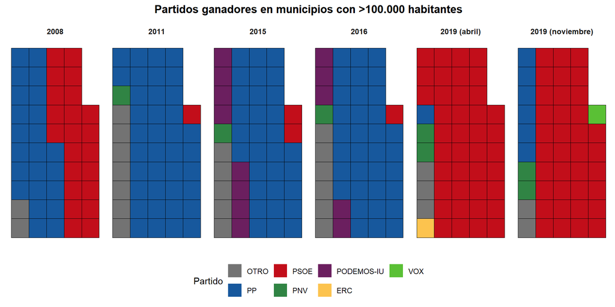

```r
colores_partidos <- c("OTRO" = "grey45", "PP" = "#17589d", "PNV" = "#308444",
                      "PODEMOS-IU" = "#6b1f5f", "VOX" = "#5ac035",
                      "PSOE" = "#c20e1a", "ERC" = "#fcc34e", "BNG" = "#76b3dd",
                      "C's" = "#fb5000")

ggplot(datos_p1, aes(fill = siglas, values = n)) +
  geom_waffle(n_rows = 10) +
  facet_grid(~eleccion) +
  scale_fill_manual(values = colores_partidos) +
  labs(title = "Partidos ganadores en municipios con >100.000 habitantes",
         fill = "Partido") +
  theme_minimal() +
  theme(
    legend.position = "bottom",
    axis.text = element_blank(),
    strip.text = element_text(face = "bold",
                              size =9),
    plot.title = element_text(face = "bold",
                              hjust = 0.5,
                              margin = margin(b = 10)),
    panel.grid = element_blank())
```

# Segunda pregunta

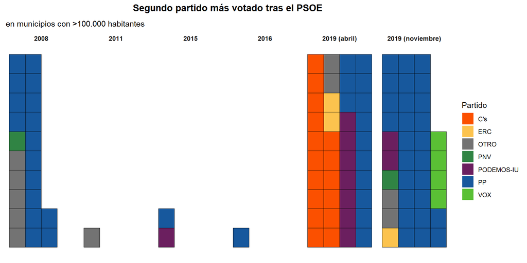

```r
# DATOS PREGUNTA 2

datos_p2_previo <-
  tabla_maestra |>
  filter(censo > 100000) |>
  slice_max(votos_totales_partido, by = c(anno, mes, cod_poblacion)) |>
  distinct(anno, mes, municipio, cod_poblacion, siglas)

# Apartado a: El PSOE es el primer partido

datos_p2_psoe_prim <-
  datos_p2_previo |>
  filter(siglas == "PSOE")

datos_p2_a <-
  tabla_maestra |>
  filter(censo > 100000) |>
  distinct(anno, mes, municipio, cod_poblacion, siglas, votos_totales_partido) |>
  group_by(anno, mes, cod_poblacion) |>
  slice_max(votos_totales_partido, n = 2) |>
  mutate(rank_grupo = rank(-votos_totales_partido)) |>
  filter(rank_grupo == 2) |>
  inner_join(datos_p2_psoe_prim, by = c("cod_poblacion", "anno", "mes"), suffix = c("_seg", "_prim")) |>
  group_by(anno, mes) |>
  count(siglas_seg) |>
  ungroup() |>
  mutate(
    siglas = factor(siglas_seg, levels = unique(siglas_seg)),
    eleccion = case_when(
      anno == 2008 ~ "2008",
      anno == 2011 ~ "2011",
      anno == 2015 ~ "2015",
      anno == 2016 ~ "2016",
      anno == 2019 & mes == "04" ~
      "2019 (abril)",
      anno == 2019 & mes == "11" ~
        "2019 (noviembre)"
    )
  )

# Gráfico para ver qué partidos son los segundos más votados cuando el PSOE es el primero
ggplot(datos_p2_a, aes(fill = siglas_seg, values = n)) +
  geom_waffle(n_rows = 10) +
  facet_grid(~eleccion) +
  scale_fill_manual(values = colores_partidos) +
  labs(title = "Segundo partido más votado tras el PSOE",
       subtitles = "en municipios con >100.000 habitantes",
         fill = "Partido") +
  theme_minimal() +
  theme(
    legend.position = "right",
    axis.text = element_blank(),
    strip.text = element_text(face = "bold",
                              size =9),
    plot.title = element_text(face = "bold",
                              hjust = 0.5,
                              margin = margin(b = 10)),
    panel.grid = element_blank())
```

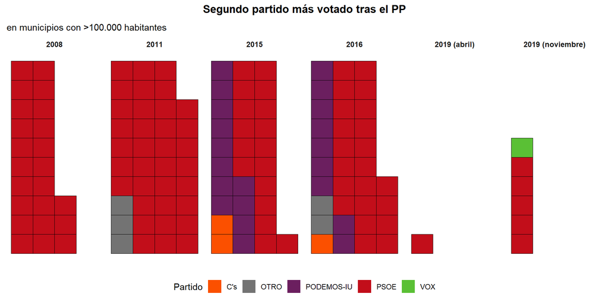

```r
# DATOS PREGUNTA 2
# Apartado b: El PP es el primer partido

datos_p2_pp_prim <-
  datos_p2_previo |>
  filter(siglas == "PP")


datos_p2_b <-
  tabla_maestra |>
  filter(censo > 100000) |>
  distinct(anno, mes, municipio, cod_poblacion, siglas, votos_totales_partido) |>
  group_by(anno, mes, cod_poblacion) |>
  slice_max(votos_totales_partido, n = 2) |>
  mutate(rank_grupo = rank(-votos_totales_partido)) |>
  filter(rank_grupo == 2) |>
  inner_join(datos_p2_pp_prim, by = c("cod_poblacion", "anno", "mes"), suffix = c("_seg", "_prim")) |>
  group_by(anno, mes) |>
  count(siglas_seg) |>
  ungroup() |>
  mutate(
    siglas = factor(siglas_seg, levels = unique(siglas_seg)),
    eleccion = case_when(
      anno == 2008 ~ "2008",
      anno == 2011 ~ "2011",
      anno == 2015 ~ "2015",
      anno == 2016 ~ "2016",
      anno == 2019 & mes == "04" ~
      "2019 (abril)",
      anno == 2019 & mes == "11" ~
        "2019 (noviembre)"
    )
  )

# Gráfico para ver qué partidos son los segundos más votados cuando el PSOE es el primero
ggplot(datos_p2_b, aes(fill = siglas_seg, values = n)) +
  geom_waffle(n_rows = 10) +
  facet_grid(~eleccion) +
  scale_fill_manual(values = colores_partidos) +
  labs(title = "Segundo partido más votado tras el PP",
       subtitle = "en municipios con >100.000 habitantes",
         fill = "Partido") +
  theme_minimal() +
  theme(
    legend.position = "bottom",
    axis.text = element_blank(),
    strip.text = element_text(face = "bold",
                              size =9),
    plot.title = element_text(face = "bold",
                              hjust = 0.5,
                              margin = margin(b = 10)),
    panel.grid = element_blank())
```

# Tercera pregunta

¿Cómo calibrar el error de las encuestas (recordemos que las encuestas son de intención de voto a nivel nacional)?

Resultados de las elecciones:

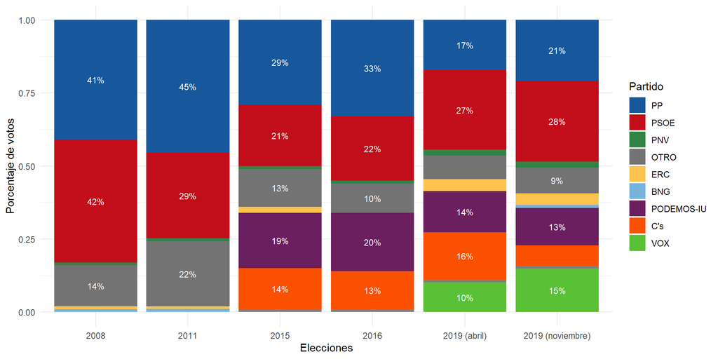

```r
# Preparamos los resultados de las elecciones, vemos qué porcentaje de votos ha ido a cada partido

datos_generales_elecciones <-
  tabla_maestra |>
  group_by(anno,mes) |>
  distinct(anno, mes, cod_poblacion, codigo_ccaa, codigo_provincia, codigo_municipio, codigo_distrito_electoral, censo, votos_blancos, votos_nulos, votos_candidaturas) |>
  mutate(censo = sum(censo),
         votos_blancos = sum(votos_blancos),
         votos_nulos = sum(votos_nulos),
         votos_candidaturas = sum(votos_candidaturas),
         eleccion = case_when(
            anno == 2008 ~ "2008",
            anno == 2011 ~ "2011",
            anno == 2015 ~ "2015",
            anno == 2016 ~ "2016",
            anno == 2019 & mes == "04" ~
            "2019 (abril)",
            anno == 2019 & mes == "11" ~
              "2019 (noviembre)")) |>
  ungroup() |>
  distinct(eleccion, censo, votos_blancos, votos_nulos, votos_candidaturas)

datos_partido <-
  tabla_maestra |>
  group_by(anno, mes, siglas) |>
  mutate(votos_partido = sum(votos),
         eleccion = case_when(
            anno == 2008 ~ "2008",
            anno == 2011 ~ "2011",
            anno == 2015 ~ "2015",
            anno == 2016 ~ "2016",
            anno == 2019 & mes == "04" ~
            "2019 (abril)",
            anno == 2019 & mes == "11" ~
              "2019 (noviembre)")) |>
  ungroup() |>
  distinct(eleccion, siglas, votos_partido) |>
  left_join(datos_generales_elecciones, by = c("eleccion" = "eleccion")) |>
  mutate(votos_porc_votantes_cand = round(votos_partido / votos_candidaturas, 2), # Porcentaje sobre la gente que voto candidaturas
         votos_porc_censo = round(votos_partido / censo, 2)) # Porcentaje sobre la gente censada,

datos_partido <-
  datos_partido |>
  mutate(siglas = factor(siglas, levels = c("PP","PSOE","PNV","OTRO","ERC","BNG","PODEMOS-IU","C's","EH-BILDU","VOX"),
                         ordered = TRUE))


grafico_resultados_elecciones <-
  ggplot(datos_partido, aes(x = eleccion, y = votos_porc_votantes_cand, fill = siglas)) +
  geom_col(position = "fill") +
    geom_text(
    aes(
      label = ifelse(votos_porc_votantes_cand > 0.08, scales::percent(votos_porc_votantes_cand, accuracy = 1), ""),
      y = votos_porc_votantes_cand / 2
    ),
    position = position_fill(vjust = 0.5),
    size = 3,
    color = "white"
  ) +
  scale_fill_manual(values = colores_partidos) +
  labs(
    x = "Elecciones",
    y = "Porcentaje de votos",
    fill = "Partido"
  ) +
  theme_minimal()
grafico_resultados_elecciones
```

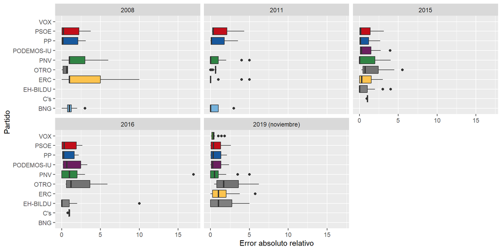

```r
# Preparamos los datos de las encuestas, vemos qué porcentaje de votantes se estiman para cada partido

surveys_general <-
  surveys_tidy |>
  distinct(date_elec, pollster, field_date_from, size, turnout) |>
  #filter(id_pollster == "pollster-49" & date_elec== "2011-11-20")
  mutate(personas_turnout = round((size * turnout)/100),0) |>
  group_by(date_elec, pollster) |>
  mutate(size = sum(size),
         personas_turnout = sum(personas_turnout, na.rm = TRUE)) |>
  distinct(date_elec, pollster, size, personas_turnout)


surveys_partido <-
  surveys_tidy |>
  mutate(votantes = round(((size - turnout)*intencion_voto)/100, 0)) |>
  group_by(date_elec, pollster, siglas) |>
  mutate(votantes_estimados = sum(votantes, na.rm = TRUE)) |>
  distinct(date_elec, pollster, siglas, votantes_estimados) |>
  left_join(surveys_general, by = c("date_elec" = "date_elec", "pollster" = "pollster")) |>
  mutate(votos_porc_votantes_cand = round(votantes_estimados / (size - personas_turnout), 2),
         votos_porc_censo = round(votantes_estimados / size, 2),
         eleccion =  case_when(
            year(date_elec) == 2008 ~ "2008",
            year(date_elec)  == 2011 ~ "2011",
            year(date_elec)  == 2015 ~ "2015",
            year(date_elec)  == 2016 ~ "2016",
            year(date_elec)  == 2019 & month(date_elec)  == "04" ~
            "2019 (abril)",
            year(date_elec)  == 2019 &  month(date_elec) == "11" ~
              "2019 (noviembre)"))  |>
  group_by(eleccion, siglas) |>
  mutate(media_porc_encuesta = mean(votos_porc_votantes_cand)) |>
  ungroup()

# Comparamos los datos reales vs los de las encuestas
comparacion <-
  left_join(x = surveys_partido, y = datos_partido, by = c("eleccion" = "eleccion", "siglas" = "siglas")) |>
  select (eleccion, pollster, siglas, votos_porc_votantes_cand.x, votos_porc_votantes_cand.y, votos_porc_censo.x, votos_porc_censo.y) |>
  mutate(error_relativo_cand = abs(votos_porc_votantes_cand.y - votos_porc_votantes_cand.x) / votos_porc_votantes_cand.y,
         error_relativo_censo = abs(votos_porc_censo.y - votos_porc_censo.x) / votos_porc_censo.y) |>
  drop_na(eleccion)

grafico_comparacion_partido <-
  ggplot(comparacion, aes(x = error_relativo_cand, y = siglas, fill = siglas)) +
  geom_boxplot() +
  facet_wrap(~eleccion) +
  scale_fill_manual(values = colores_partidos)  +
    labs(
    x = "Error absoluto relativo",
    y = "Partido",
    fill = "Partido"
  ) +
  guides(fill = "none")
grafico_comparacion_partido
```

Parece que hay algunas empresas encuestadoras que se desvían más que otras, ver cómo poner este gráfico por años

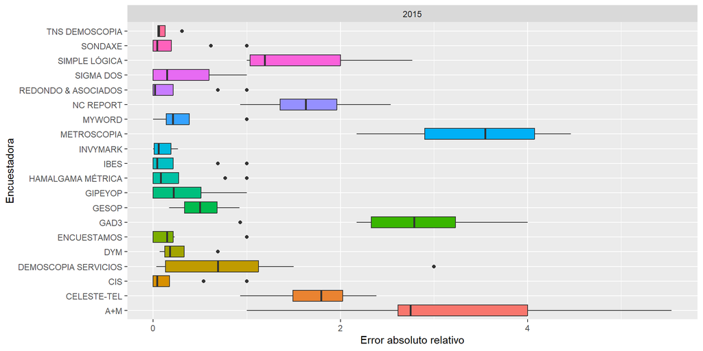

```r
grafico_comparacion_pollster <-
  comparacion |>
  filter(eleccion == "2015") |>
  ggplot( aes(x = error_relativo_cand, y = pollster, fill = pollster)) +
  geom_boxplot() +
  labs(
    x = "Error absoluto relativo",
    y = "Encuestadora",
    fill = "Encuestadora"
  ) +
  guides(fill = "none") +
  facet_wrap(~eleccion)
grafico_comparacion_pollster
```

# PREGUNTA 4

### ¿Relación entre censo y voto?

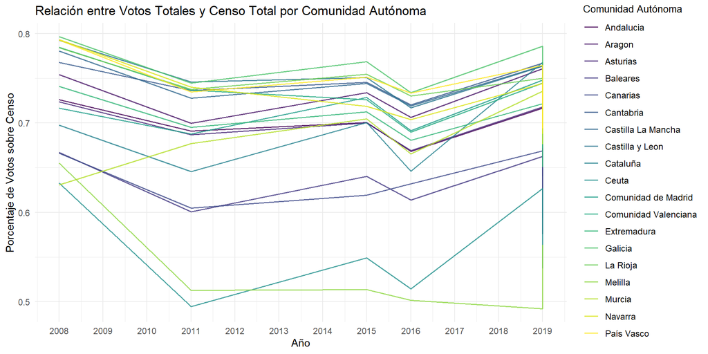

```r
tabla_pg4 <-
  tabla_maestra |>
  # Votos totales por población
  group_by(anno, mes, codigo_ccaa, codigo_provincia, codigo_municipio, cod_poblacion) |>
  summarise(votos_totales = sum(votos)) |>
  distinct(anno, codigo_ccaa, codigo_provincia, codigo_municipio, cod_poblacion, votos_totales)

tabla_pg4_censo <-
  tabla_maestra |>
  distinct(anno, mes, codigo_ccaa, codigo_provincia, codigo_municipio, cod_poblacion, censo)

tabla_pg4_censoxvotos <-
  left_join(x = tabla_pg4_censo,
            y = tabla_pg4,
            by = c("anno" = "anno",
                   "mes" = "mes",
                   "codigo_ccaa" = "codigo_ccaa",
                   "codigo_provincia" = "codigo_provincia",
                   "codigo_municipio" = "codigo_municipio",
                   "cod_poblacion" = "cod_poblacion")) |>
  group_by(anno, mes, codigo_ccaa) |>
  summarise(censo_tot = sum(censo), votos_tot = sum(votos_totales)) |>
  mutate(
    porc = votos_tot / censo_tot,
    comunidad_autonoma = case_when(
      codigo_ccaa == "01" ~ "Andalucia",
      codigo_ccaa == "02" ~ "Aragon",
      codigo_ccaa == "03" ~ "Asturias",
      codigo_ccaa == "04" ~ "Baleares",
      codigo_ccaa == "05" ~ "Canarias",
      codigo_ccaa == "06" ~ "Cantabria",
      codigo_ccaa == "07" ~ "Castilla y Leon",
      codigo_ccaa == "08" ~ "Castilla La Mancha",
      codigo_ccaa == "09" ~ "Cataluña",
      codigo_ccaa == "10" ~ "Comunidad Valenciana",
      codigo_ccaa == "11" ~ "Extremadura",
      codigo_ccaa == "12" ~ "Galicia",
      codigo_ccaa == "13" ~ "Comunidad de Madrid",
      codigo_ccaa == "14" ~ "Murcia",
      codigo_ccaa == "15" ~ "Navarra",
      codigo_ccaa == "16" ~ "País Vasco",
      codigo_ccaa == "17" ~ "La Rioja",
      codigo_ccaa == "18" ~ "Ceuta",
      TRUE ~ "Melilla"
    )
  )

# Graficar los datos
ggplot(tabla_pg4_censoxvotos) +
  geom_line(aes(x = anno, y = porc, color = comunidad_autonoma), size = 0.7, alpha = 0.8) +
  scale_x_continuous(
    breaks = seq(2007, 2020, by = 1),
    labels = seq(2007, 2020, by = 1)
  ) +
  scale_color_viridis_d() +
  labs(
    title = "Relación entre Votos Totales y Censo Total por Comunidad Autónoma",
    x = "Año",
    y = "Porcentaje de Votos sobre Censo",
    color = "Comunidad Autónoma"
  ) +
  theme_minimal() +
  theme(
    legend.title = element_text(size = 10),
    legend.text = element_text(size = 9)
  )
```

Las comunidades tienen diferentes niveles de participación. Algunas mantienen un porcentaje más alto (cerca del 80%), mientras que otras caen a valores significativamente más bajos (alrededor del 50% en algunos años).

## Evolución del Porcentaje de Voto en Relación al Censo por Comunidad Autónoma

```r
#animación gráfico
tabla_pg4_censoxvotos <- tabla_pg4_censoxvotos |>
  mutate(anno = as.integer(anno))

# Crear el gráfico animado
gplot <- ggplot(tabla_pg4_censoxvotos) +
  aes(x = anno, y = porc, color = comunidad_autonoma) +
  geom_line(aes(linetype = as.factor(codigo_ccaa)), size = 0.7, alpha = 0.8) +
  scale_x_continuous(
    breaks = seq(2007, 2020, by = 1),
    labels = seq(2007, 2020, by = 1)
  ) +
  scale_color_viridis_d() +
  labs(
    title = "Relación entre Censo y Voto",
    x = "Año",
    y = "Porcentaje de Voto",
    color = "Comunidad Autónoma"
  ) +
  theme_minimal() +
  theme(
    legend.title = element_text(size = 10),
    legend.text = element_text(size = 9)
  ) +
  transition_reveal(anno) +
  ease_aes('linear')

anim_save("Relación_Censo_Voto.gif", gplot)
```

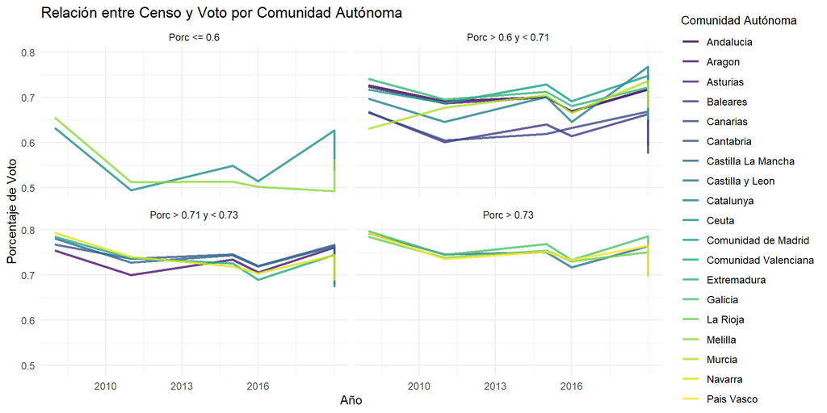

```r
# Crear tabla con votos totales por población
tabla_pg4 <-
  tabla_maestra |>
  group_by(anno, mes, codigo_ccaa, codigo_provincia, codigo_municipio, cod_poblacion) |>
  summarise(votos_totales = sum(votos)) |>
  distinct(anno, codigo_ccaa, codigo_provincia, codigo_municipio, cod_poblacion, votos_totales)

# Crear tabla con el censo
tabla_pg4_censo <-
  tabla_maestra |>
  distinct(anno, mes, codigo_ccaa, codigo_provincia, codigo_municipio, cod_poblacion, censo)

# Unir las dos tablas y calcular porcentaje de votos sobre censo
tabla_pg4_censoxvotos <-
  left_join(x = tabla_pg4_censo,
            y = tabla_pg4,
            by = c("anno" = "anno",
                   "mes" = "mes",
                   "codigo_ccaa" = "codigo_ccaa",
                   "codigo_provincia" = "codigo_provincia",
                   "codigo_municipio" = "codigo_municipio",
                   "cod_poblacion" = "cod_poblacion")) |>
  group_by(anno, mes, codigo_ccaa) |>
  summarise(censo_tot = sum(censo), votos_tot = sum(votos_totales)) |>
  mutate(porc = votos_tot / censo_tot,
         comunidad_autonoma = case_when(
           codigo_ccaa == "01" ~ "Andalucia",
           codigo_ccaa == "02" ~ "Aragon",
           codigo_ccaa == "03" ~ "Asturias",
           codigo_ccaa == "04" ~ "Baleares",
           codigo_ccaa == "05" ~ "Canarias",
           codigo_ccaa == "06" ~ "Cantabria",
           codigo_ccaa == "07" ~ "Castilla y Leon",
           codigo_ccaa == "08" ~ "Castilla La Mancha",
           codigo_ccaa == "09" ~ "Catalunya",
           codigo_ccaa == "10" ~ "Comunidad Valenciana",
           codigo_ccaa == "11" ~ "Extremadura",
           codigo_ccaa == "12" ~ "Galicia",
           codigo_ccaa == "13" ~ "Comunidad de Madrid",
           codigo_ccaa == "14" ~ "Murcia",
           codigo_ccaa == "15" ~ "Navarra",
           codigo_ccaa == "16" ~ "Pais Vasco",
           codigo_ccaa == "17" ~ "La Rioja",
           codigo_ccaa == "18" ~ "Ceuta",
           TRUE ~ "Melilla"
         )) |>
  group_by(codigo_ccaa) |>
  mutate(mean_porc = mean(porc),
         tipos_ccaa = case_when(
           mean_porc > 0.74 ~ "Porc > 0.73",
           mean_porc > 0.71 ~ "Porc > 0.71 y < 0.73",
           mean_porc > 0.6 ~ "Porc > 0.6 y < 0.71",
           TRUE ~ "Porc <= 0.6"
         ))

# Graficar los datos
ggplot(tabla_pg4_censoxvotos) +
  geom_line(aes(x = anno, y = porc, color = comunidad_autonoma), size = 1, alpha = 0.8) +
  scale_x_continuous(
    breaks = seq(2007, 2018, by = 3),
    labels = seq(2007, 2018, by = 3)
  ) +
  scale_color_viridis_d() +  # Utilizar la paleta viridis
  labs(
    title = "Relación entre Censo y Voto por Comunidad Autónoma",
    x = "Año",
    y = "Porcentaje de Voto",
    color = "Comunidad Autónoma"
  ) +
  facet_wrap(~ tipos_ccaa) +  # Dividir en facetas por tipo de porcentaje
  theme_minimal() +
  theme(
    legend.title = element_text(size = 10),
    legend.text = element_text(size = 9)
  )
```

Se observan disparidades en la participación electoral por comunidad autónoma, con Ceuta y Melilla (<60 %) en el nivel más bajo y comunidades como La Rioja y País Vasco (> 70%) en el más alto.

### Diferencia entre zonas rurales de urbanas.

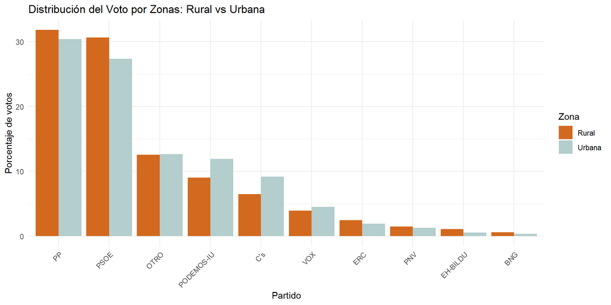

```r
#diferenciar zonas rurales de urbanas
tabla_maestra <- tabla_maestra |>
  mutate(zona = case_when(
    censo < 10000 ~ "rural",
    TRUE ~ "urbano"
  ))

resultados_rurales <- tabla_maestra |>
  filter(zona == "rural") |>
  group_by(siglas) |>
  summarise(votos_totales = sum(votos)) |>
  mutate(porcentaje_votos_rural = (votos_totales / sum(votos_totales)) * 100)

resultados_urbanos <- tabla_maestra |>
  filter(zona == "urbano") |>
  group_by(siglas) |>
  summarise(votos_totales = sum(votos)) |>
  mutate(porcentaje_votos_urbana = (votos_totales / sum(votos_totales)) * 100)

resultados_comparados <- resultados_rurales |>
  inner_join(resultados_urbanos, by = "siglas") |>
  select(siglas, porcentaje_votos_rural, porcentaje_votos_urbana) |>
  mutate(votos_totales = porcentaje_votos_rural + porcentaje_votos_urbana)

resultados_top10 <- resultados_comparados |>
  arrange(desc(votos_totales)) |>
  head(10)

datos_procesados <- resultados_top10 |>
  pivot_longer(cols = c(porcentaje_votos_rural, porcentaje_votos_urbana),
               names_to = "zona",
               values_to = "porcentaje_votos")
#graficar
datos_procesados |>
  ggplot(aes(x = reorder(siglas, -porcentaje_votos), y = porcentaje_votos, fill = zona)) +
  geom_bar(stat = "identity", position = position_dodge()) +
  scale_fill_manual(values = c("#D2691E", "#B4CDCD"),
                    labels = c("Rural", "Urbana")) +
  labs(
    title = "Distribución del Voto por Zonas: Rural vs Urbana",
    x = "Partido",
    y = "Porcentaje de votos",
    fill = "Zona",
  ) +
  theme_minimal() +
  theme(axis.text.x = element_text(angle = 45, hjust = 1)) +
  theme(legend.position = "right")
```

La diferencia entre las zonas rurales y urbanas no parece ser tan marcada en términos generales

Mientras los partidos como PP y PSOE tienen una fuerte presencia en ambas zonas, en las zonas rurales el PP obtiene una ligera ventaja. En cambio, partidos más pequeños como VOX o ERC tienen una representación más significativa en ciertas áreas específicas, pero no dominan ninguna zona.